# Statistical Methods for Bullet Matching

Eric Riemer Hare

## Statistical Methods for Bullet Matching

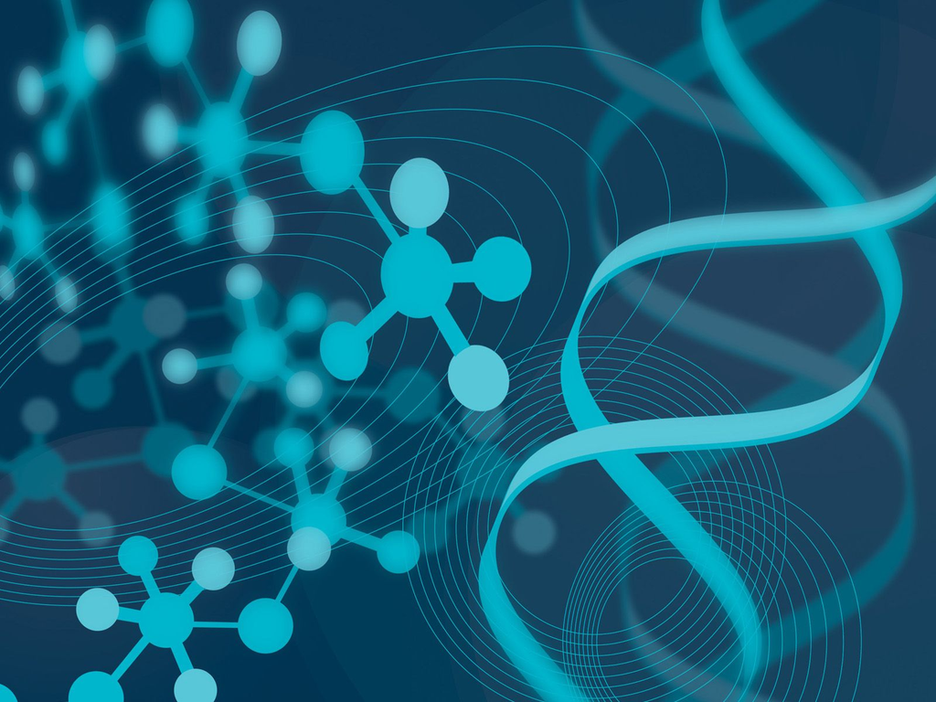

Eric Hare  
Iowa State University  
April 5th, 2017

## About Me

- Graduated in 2008 from Snohomish High School in Snohomish, WA (1 Hour Northeast of Seattle)
- Bachelor of Science with a major in Statistics (University of Washington, June 2012)
- Bachelor of Science in Computer Engineering (University of Washington, June 2012)
- Began graduate studies at Iowa State University in August 2012
- Master of Science in Statistics (Iowa State University, 2014)
- Declared Co-Major in Statistics and Computer Science, 2014
- Accepted a job as Chief Data Scientist at Omni Analytics Group

## Publications

- Hare, E., Hofmann, H., and Carriquiry, A., **Automatic Matching of Bullet Lands**. Submitted to AoAS
- Hare, E., and Kaplan, A., **Introductory Statistics with intRo**. Accepted by JCGS
- Hare, E., Buja, A., and Hofmann, H., **Manipulation of Discrete Random Variables with discreteRV**. R Journal Vol. 7 Iss. 1 (2015)
- Sieber, T., Hare, E., Hofmann, H., and Treppel, M., **Biomathematical description of synthetic Peptide libraries**. PLOS One Vol. 10 Iss. 6 (2015)
- Kaplan, A., and Hare, E., Putting Down Roots: **A Graphical Exploration of Community Attachment** (Accepted in Computational Statistics)
- Kaplan, A., Hare, E., Hofmann, H., and Cook, D., **Can you buy a president? Politics after the Tillman Act**. CHANCE Vol. 27 Iss. 1 (2014)

## Awards

- ASA Imaging Section Student Paper Award, Automatic Matching of Bullet Lands, Received 2016
- Ron Wasserstein Award for Best Contributed Paper in Statistical Education, Introductory Statistics with intRo, Received 2015
- ASA Computing Section Student Paper Award, Introductory Statistics with intRo, Received 2015
- Kempthorne Award for Best Student in Linear Models, Received 2013
- ASA Data Exposition - 1st Place, Received 2013

## Dissertation Outline

**Statistical Methods for Bullet Matching**

Papers:

1. Automatic Matching of Bullet Lands
2. Bullet Land Feature Analysis
3. A Modern Bullet Matching Application

## Automatic Matching of Bullet Lands

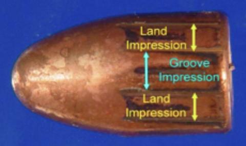

Eric Hare, Heike Hofmann, Alicia Carriquiry  
Center for Statistics and Applications in Forensic Evidence (CSAFE)

## Goal

- We wish to determine whether two bullets were fired from the same gun barrel
- Striation patterns, or individual characteristics, are unique to barrels and fairly stable (Xie 2009)
- Forensic Examiners shoot bullets from guns of suspects, compare it to bullet recovered from crime scene

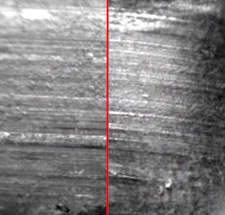

## Current Practice

- Traditionally, the bullets are placed under comparison microscopes and manually aligned by forensic scientists so that they can be compared
- (Arbitrary) Thresholds have been established as “standard practice” (e.g., more than 6 consecutively matching striae to declare a match, Nichols (2003))
- However, this has traditionally been less than statistical and such practices have come under fire in the courtroom (Giannelli 2011)

The problems culminated in a 2009 NAS report which found *“much forensic evidence – including, for example, bite marks and firearm and toolmark identification is introduced in criminal trials without any meaningful scientific validation, determination of error rates, or reliability testing.”* (National Research Council 2009)

## PCAST Report

From a September 2016 report by the President’s Council of Advisors on Science and Technology (PCAST) titled **Forensic Science in Criminal Courts: Ensuring Scientific Validity of Feature-Comparison Methods** (Advisors on Science and Technology 2016):

```
A second—and more important—direction is (as with latent print analysis)
to convert firearms analysis from a subjective method to an objective
method. This would involve developing and testing image-analysis
algorithms for comparing the similarity of tool marks on bullets. [...]
In a recent study, researchers used images from an earlier study to
develop a computer-assisted approach to match bullets that minimizes
human input [338].
```

338: Hare, E., Hofmann, H., and A. Carriquiry. “Automatic matching of bullet lands.” Unpublished paper, available at: arxiv.org/pdf/1601.05788v2.pdf.

## Our Approach

- Using a *reference database* of 3D bullet scans, compute distributional differences between **known matches** (bullets known to be fired from the same gun barrel), and **known non-matches** (bullets known to be fired from different barrels)
- Derive a set of features which separate these two classes
- Use the features to train a statistical model
- Predict on unknown pairs of bullets the probability of being a match

The key to this approach is the *reference database*…

## James Hamby Study

- Ten consecutively rifled Ruger P-85 pistol barrels used to fire 20 “known” test bullets and 15 “unknown” bullets for comparison (Hamby, Brundage, and Thorpe 2009)
- Sets of 35 bullets sent to 507 Forensic Examiners for examination
- 0 false positive identifications, 8 inconclusive results (out of 7605)
- Can an automated algorithm do as well?

```r
plot3D.x3p.file(read_x3p("../images/Hamby (2009) Barrel/bullets/Br1 Bullet 1-5.x3p"),
plot.type = "surface")
```

[output not shown]

## Data Format

- 3D topographical images of each bullet
- x3p format, array of surface measurements at the micrometer level
- R package *x3pr* available for working with these images (Nicholas Petraco, John Jay College, OpenFMC (2014))
- R package *bulletr* (Hofmann and Hare 2016) with a more streamlined image reading routine and additional statistical functionality
- Each bullet is a set of 6 land-to-land scans

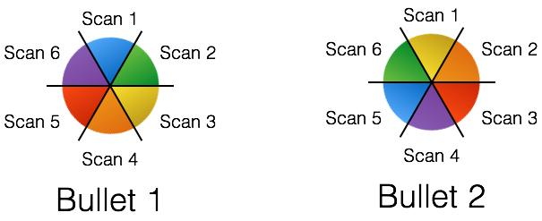

## Step One: Extract a Profile

We need to choose a location (height) of the bullet at which to extract a profile. To do so, we optimize the **CCF** (T. Vorburger et al. 2011):

1. Extract a profile near the base of the bullet, call this value *d*<sub>0</sub>.
2. Take a fixed step *d* and extract at *d* + *d*<sub>0</sub>.
3. Check the maximum cross correlation (CCF) between the signature at *d*<sub>0</sub> and at *d* + *d*<sub>0</sub>.
4. If this CCF exceeds a threshold *c*, choose *d*<sub>0</sub> as the signature
5. Otherwise, repeat steps 2 to 4 for *d*, 2*d*, 3*d*, … until the threshold is achieved.
6. If the threshold is not achieved, flag the land for further investigation.

Parameters: *d* = 25*μ**m*, *d*<sub>0</sub> = 25*μ**m*, *c* = 0.9

## Step One (Continued)

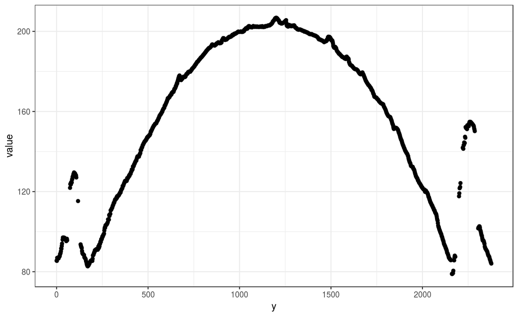

```r
br111 <- get_crosscut("images/Br1 Bullet 1-5.x3p", x = 243.75)

qplot(y, value, data = br111) + theme_bw()
```

## Step Two: Remove Shoulders

The striations that identify a bullet to a gun barrel are located in the land impression areas (Xie et al. 2009).

Parameters: *s* = 35*μ**m*

## Identifying Shoulders (Easy)

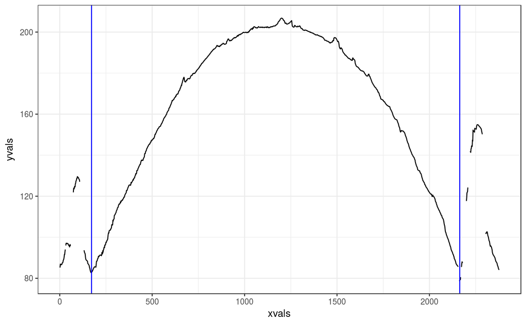

```r
br111.groove <- get_grooves(br111)
br111.groove$plot
```

## Identifying Shoulders (Challenging)

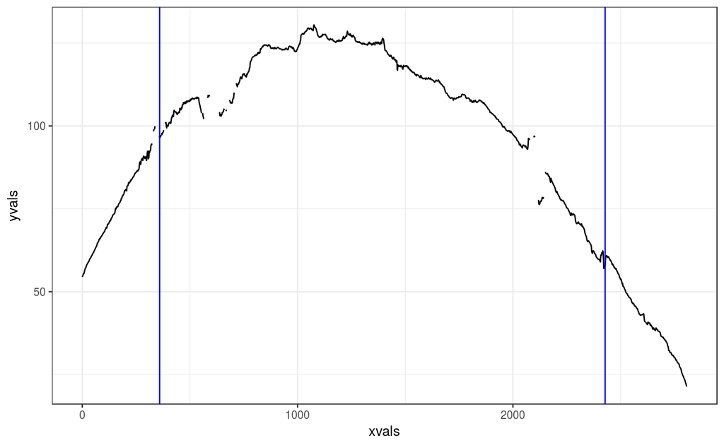

```r
result2 <- get_grooves(get_crosscut("../images/Hamby (2009) Barrel/bullets/Br1 Bullet 1-6.x3p"))
result2$plot
```

## Step Three: Fit Loess Regression

Local weighted scatterplot smoothing (Cleveland 1979) - Fits a low-degree polynomial to a small subset of the data, weighting values near the point to be estimated more strongly.

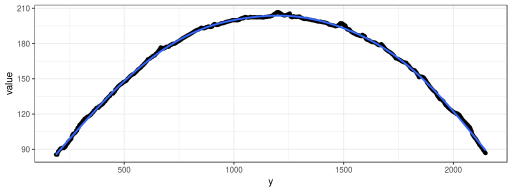

```r
br111.loess <- fit_loess(br111, br111.groove)
br111.loess$fitted
```

## Step Four: Get the Residuals

Deviations from the loess fit should represent the imperfections (striations) on the bullet. Hence, we extract the residuals from the model.

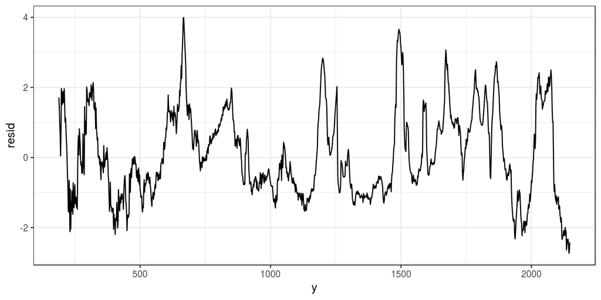

```r
br111.loess$resid
```

## Step Five: Peaks and Valleys

As with detecting the shoulders, we can smooth the deviations and compute derivatives to identify peaks and valleys in the signature.

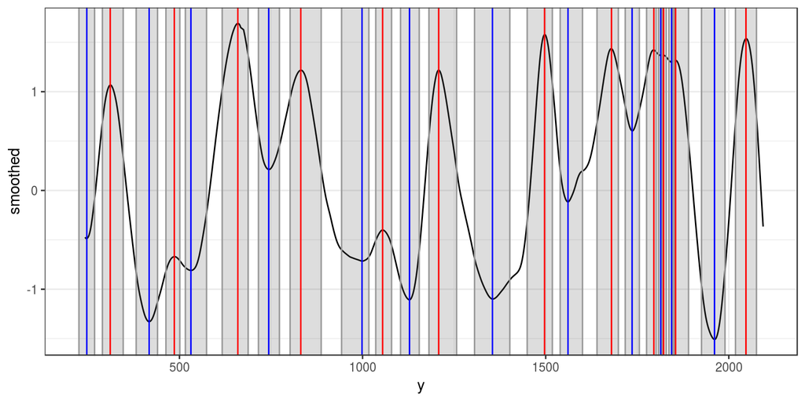

```r
br111.peaks <- get_peaks(br111.loess$data)
br111.peaks$plot
```

## Step Six: Bullet Alignment

The previous five steps are performed for each bullet land. But now we wish to extract features for cross comparisons of bullet lands.

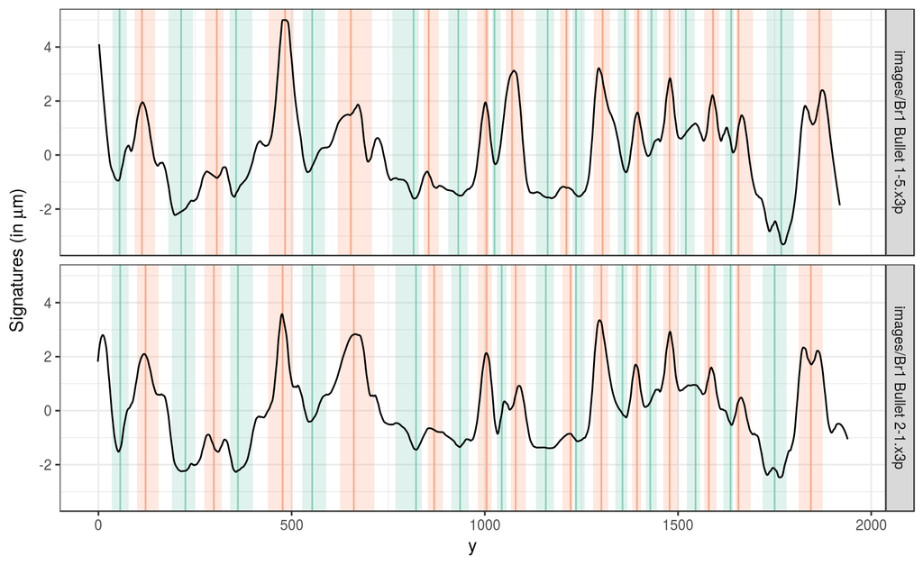

## Step Six (Continued)

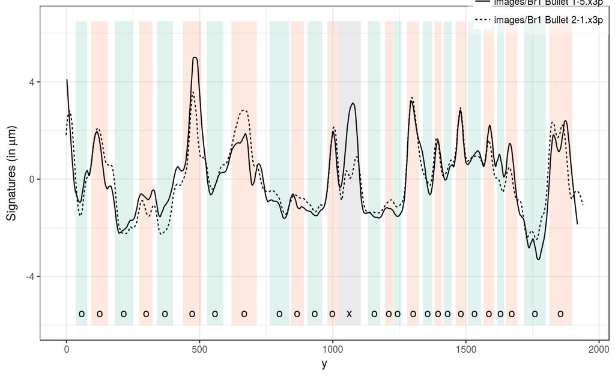

## Step Six: Extract Features

Features are extracted from each land-to-land comparison:

- **ccf** (%) is the maximum value of the Cross-Correlation function evaluated at the optimal alignment. The CCF is defined as *C*(*τ*)=∫<sub>−∞</sub><sup>∞</sup>*f*(*t*)*g*(*t* + *τ*)*d**t* where *τ* represents the the lag of the second signature (T. Vorburger et al. 2011).
- **rough_cor** (%) is a new feature representing the correlation between the two signatures after performing a second LOESS smoothing stage and subtracting the result from the original signatures.
- **D** (mm) is the Euclidean vertical distance between each height value of the aligned signatures. This is defined as *D*<sup>2</sup> = 1/*n* × ∑<sub>*t*</sub>(*f*(*t*)−*g*(*t*))<sup>2</sup>. This is a measure of the total variation between two functions (Clarkson and Adams 1933).

## More Features

- **matches** (per mm) is the number of matching peaks/valleys (striae) per millimeter of the overlapping portion of the aligned signatures.
- **mismatches** (per mm) is the number of mismatching peaks/valleys (striae) per millimeter of the overlapping portion of the aligned signatures.
- **cms** (per mm) is the number of consecutively matching peaks/valleys (striae) per millimeter of the overlapping portion of the aligned signatures (Biasotti 1959, W. Chu et al. (2013)).
- **non_cms** (per mm) is the number of consecutive mismatching peaks/valleys (striae) per millimeter of the overlapping portion of the aligned signatures.
- **sum_peaks** (per mm) is the the sum of the average heights of matched striae.

## Distribution of Features

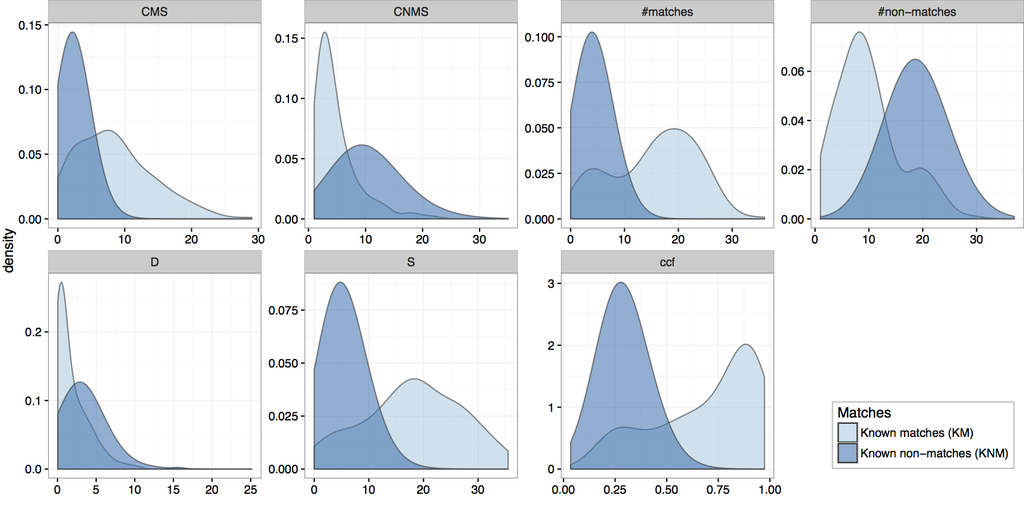

## Step Seven: Random Forest

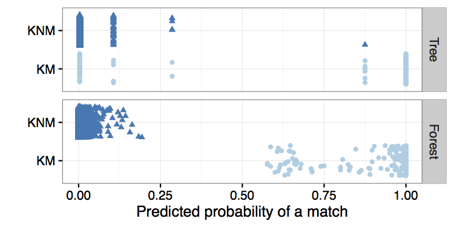

## Feature Importance

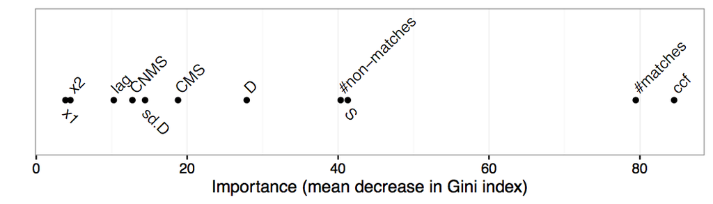

## Web Application

https://isu-csafe.stat.iastate.edu/shiny/bulletr/

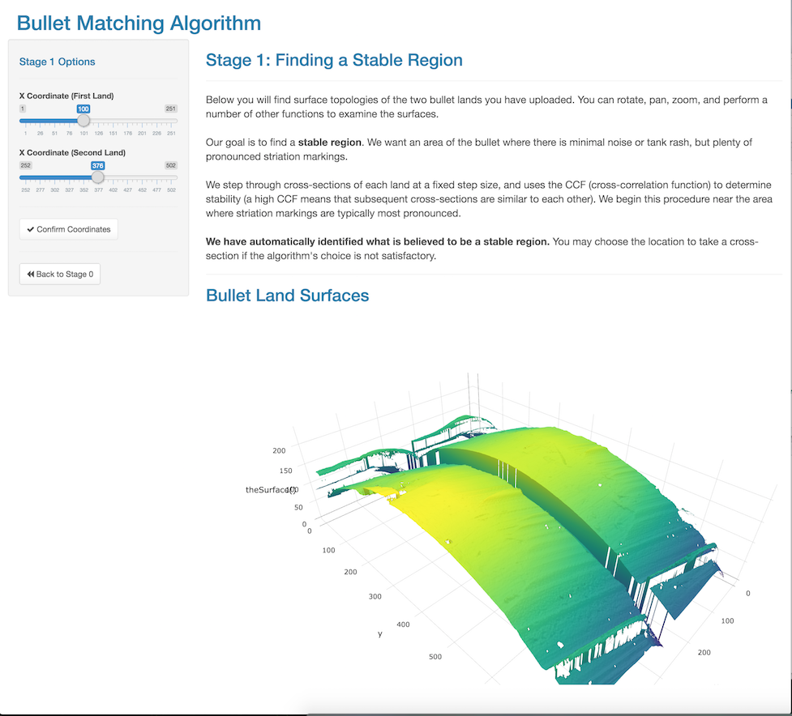

## Previous Future Work

Verbatim from September:

- We are extremely limited by data here - Currently we’ve only assessed this algorithm on one particular set of 35 bullets
- There is likely an effect from the equipment used to scan the bullets, or the person performing the scan, and this should be accounted for
- We need to assess the quality of the algorithm in case we don’t have full bullet lands available, as is the case in many forensics applications (degraded bullets)
- This future work will be part of a follow-up paper, in progress.

We have steps to address each of these concerns…

## Thank You

Special thanks to Alan Zheng at the National Institute of Standards and Technology for maintaining the NIST Ballistics Toolmark Research Database and providing many useful suggestions for our algorithm.

- My GitHub: https://github.com/erichare
- My Website: https://erichare.me

Any Questions?

## Bibliography

Advisors on Science, President’s Council of, and Technology. 2016. “Report on Forensic Science in Criminal Courts: Ensuring Scientific Validity of Feature-Comparison Methods.” https://www.whitehouse.gov/sites/default/files/microsites/ostp/PCAST/pcast_forensic_science_report_final.pdf.

Biasotti, Alfred A. 1959. “A Statistical Study of the Individual Characteristics of Fired Bullets.” *Journal of Forensic Sciences* 4 (1): 34–50.

Chu, Wei, Robert M Thompson, John Song, and Theodore V Vorburger. 2013. “Automatic identification of bullet signatures based on consecutive matching striae (CMS) criteria.” *Forensic Science International* 231 (1–3): 137–41.

Clarkson, James A, and C Raymond Adams. 1933. “On Definitions of Bounded Variation for Functions of Two Variables.” *Transactions of the American Mathematical Society* 35 (4). JSTOR: 824–54.

Cleveland, William S. 1979. “Robust Locally Weighted Regression and Smoothing Scatterplots.” *Journal of the American Statistical Association* 74 (368). Taylor & Francis, Ltd.: 829–36. http://www.jstor.org/stable/2286407.

Giannelli, Paul C. 2011. “Ballistics Evidence Under Fire.” *Criminal Justice* 25 (4): 50–51.

Hamby, James E., David J. Brundage, and James W. Thorpe. 2009. “The Identification of Bullets Fired from 10 Consecutively Rifled 9mm Ruger Pistol Barrels: A Research Project Involving 507 Participants from 20 Countries.” *AFTE Journal* 41 (2): 99–110.

Hofmann, Heike, and Eric Hare. 2016. *Bulletr: Algorithms for Matching Bullet Lands*.

National Research Council. 2009. *Strengthening Forensic Science in the United States: A Path Forward*. Washington, DC: The National Academies Press. doi:10.17226/12589.

Nichols, Ronald G. 2003. “Consecutive Matching Striations (CMS): Its Definition, Study and Application in the Discipline of Firearms and Tool Mark Identification.” *AFTE Journal* 35 (3): 298–306.

OpenFMC. 2014. *X3pr: Read/Write Functionality for X3p Surface Metrology Format*.

Vorburger, T.V., J.-F. Song, W. Chu, L. Ma, S.H. Bui, A. Zheng, and T.B. Renegar. 2011. “Applications of Cross-Correlation Functions.” *Wear* 271 (3–4): 529–33. doi:http://dx.doi.org/10.1016/j.wear.2010.03.030.

Xie, F., S. Xiao, L. Blunt, W. Zeng, and X. Jiang. 2009. “Automated Bullet-Identification System Based on Surface Topography Techniques.” *Wear* 266 (5–6): 518–22. doi:http://dx.doi.org/10.1016/j.wear.2008.04.081.